# R Assignment 5

Nina Dyatchenko

September 17, 2018

## Assignment 5: Due Sunday, 23 September at 23:59PM

*For help with Rmarkdown for reports, see this [white paper](http://www.stat.cmu.edu/~cshalizi/rmarkdown/#math-in-r-markdown) from Carnegie Mellon University’s Department of Statistics and Data Science.*

**I’m giving you some additional material to read. This should help you with the exercises I’ve assigned below.**

### Read About Lists

Read the following articles:

- [Basics of Lists](http://r4ds.had.co.nz/lists.html): read until you reach the **For loops vs functionals** subsection; you don’t have to do the exercises at the end.
- [Editing Lists](https://www.datamentor.io/r-programming/list/): read entire article

Based on these lessons, here are some helpful definitions:

1. Subset a list by position or name with the `[` function
2. Subset a list by position or name and extract its *contents* with the `[[` function
3. Subset a list by name and extract its *contents* with the `$` function
4. Find the class of an object with the `class()` function.

### Examples

```r
# Create the list
x_ls <- list(a = 3L, b = "five")

# What is x_ls?
class(x_ls)
```

```
## [1] "list"
```

```r
"list"
```

```
## [1] "list"
```

#### The `[` Function

I can extract the first element of `x_ls` by name or position.

```r
# Subset by name

x_ls["a"]
```

```
## $a
## [1] 3
```

```r
# What is returned by this?
class(x_ls["a"])
```

```
## [1] "list"
```

```r
# Subset by position
x_ls[1]
```

```
## $a
## [1] 3
```

```r
# What is returned by this?
class(x_ls[1])
```

```
## [1] "list"
```

As we can see, the `[` function returns a list element. This can be helpful at times, but often we want the *contents* of that list element. The main upside to the `[` function is that we can select multiple list elements at once.

```r
x_ls[1:2]
```

```
## $a
## [1] 3
##
## $b
## [1] "five"
```

```r
# What is returned by this?
class(x_ls[1:2])
```

```
## [1] "list"
```

#### The `[[` Function

I can extract the contents of the first element of `x_ls` by name or position.

```r
# Subset by name
x_ls[["a"]]
```

```
## [1] 3
```

```r
# What is returned by this?
class(x_ls[["a"]])
```

```
## [1] "integer"
```

```r
# Subset by position
x_ls[[1]]
```

```
## [1] 3
```

```r
# What is returned by this?
class(x_ls[[1]])
```

```
## [1] "integer"
```

As we can see, the `[[` function returns the *contents* of the list element. We cannot, however, select multiple list elements with this function (try it yourself).

#### The `$` Function

I can extract the contents of the first element of `x_ls` by name only.

```r
x_ls$a
```

```
## [1] 3
```

```r
# What is returned by this?
class(x_ls$a)
```

```
## [1] "integer"
```

As we can see, the `$` function returns the *contents* of the list element. You might ask, “why do we need `$` when we have `[[`?” Notice that we didn’t need to put `a` in quotes for `$` to work (`x_ls$a`, not `x_ls$"a"`). We will come back to the idea of using names of objects later this semester.

### Review

As a complimentary example to the pepper shaker, think about this list as a train. We can select the first car of the train with the `[` function. We could select any number of cars in the train with the `[` function. Additionally, we can extract the contents of a car by name or position with the `[[` function, but we can’t select more than one car at a time. Finally, we can extract the contents of a train car by name with the `$` function; this function is special because it doesn’t require us to type the quotes (`" "`) around the name.

## Exercises

**1. Create a list with four elements:** a. the character string `"Normal"` to represent the distribution b. a named vector of the population parameters (f-n names to assign names) c. a vector of 15 samples from a normal distribution with mean 2 and variance 5 d. the components of a histogram of these samples Create in two steps: 1) a-c, 2) d- hist of samples from c.

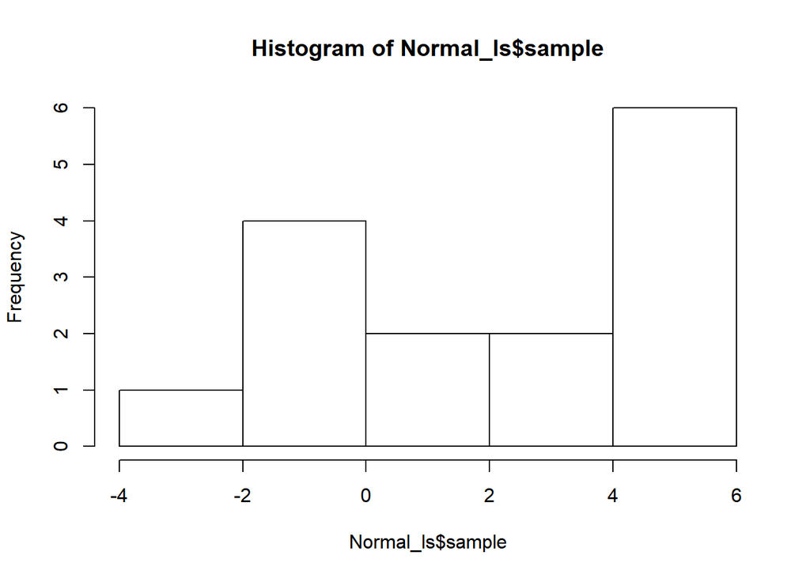

```r
Normal_ls<- list(
  DistName ="Normal",
  params = c(mu =2, var=5),
  sample = rnorm(n=15, mean=2, sd=sqrt(5))
  )

#Normal_ls[["hist"]]<- hist(Normal_ls[[3]])   # or
Normal_ls$hist<- hist(Normal_ls$sample)
```

**2. Print the distribution name and parameters (at the same time), and plot the saved histogram.**

```r
Normal_ls[c("DistName", "params")]
```

```
## $DistName
## [1] "Normal"
##
## $params
##  mu var
##   2   5
```

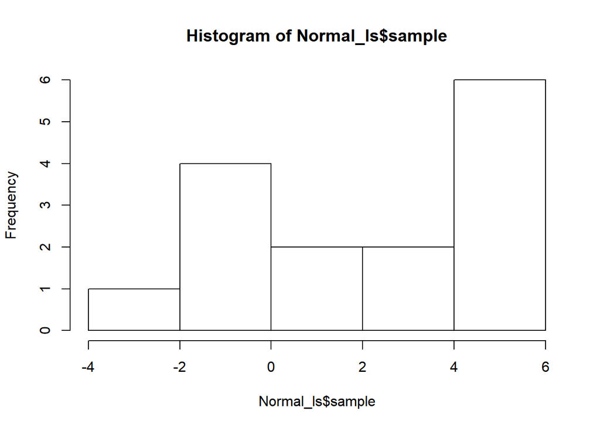

```r
hist(Normal_ls$sample)
```

**3. Print the summary and variance of this sample.**

```r
summary(Normal_ls$sample)
```

```
##    Min. 1st Qu.  Median    Mean 3rd Qu.    Max.
## -2.0522 -0.5405  3.0528  2.3311  5.3449  5.9875
```

```r
var(Normal_ls$sample)
```

```
## [1] 9.142852
```

**4. Test the hypothesis that these observations came from the distribution specified.** Store the $p$-value, test statistic, critical value, and decision (reject or fail to reject) as new elements of the list. Test if the sample mean is hypothesys test.

Discrete probability distributions: Binomial, Negative binomial, and Poisson. Continuous probability distributions: Normal, Student’s t, Chi-square, and F.

*Normal*

H0: Mean = 2 Ha: Mean is not 2

```r
mean(Normal_ls$sample)
```

```
## [1] 2.331143
```

```r
var(Normal_ls$sample)
```

```
## [1] 9.142852
```

```r
# qt(p, df, ncp, lower.tail = TRUE, log.p = FALSE)

qt(0.975, 14) # Critical Value (CV)
```

```
## [1] 2.144787
```

```r
#Test statistics:
# t.test is
# t.test(x, y = NULL,
#       alternative = c("two.sided", "less", "greater"),
#       mu = 0, paired = FALSE, var.equal = FALSE,
#       conf.level = 0.95, ...)

t_Norm <- t.test(
  Normal_ls$sample,
  alternative = "two.sided",
  mu = 2)

t_Norm # gives output about hypothesis and statistics
```

```
##
##  One Sample t-test
##
## data:  Normal_ls$sample
## t = 0.42415, df = 14, p-value = 0.6779
## alternative hypothesis: true mean is not equal to 2
## 95 percent confidence interval:
##  0.6566652 4.0056202
## sample estimates:
## mean of x
##  2.331143
```

```r
class(t_Norm)
```

```
## [1] "htest"
```

```r
is.list(t_Norm) # is a list;
```

```
## [1] TRUE
```

```r
t_Norm$statistic # statistics refers only to a t value, extracts t value from hypothesis test output
```

```
##         t
## 0.4241505
```

```r
abs(t_Norm$statistic) # absolute value of test statistics
```

```
##         t
## 0.4241505
```

```r
abs(t_Norm$statistic) > qt(0.975, 14)
```

```
##     t
## FALSE
```

```r
t_Norm$p.value # how much we are wrong
```

```
## [1] 0.6779012
```

```r
Normal_ls[["Absolute value of Test Statistics (TS)"]]<- abs(t_Norm$statistic)
Normal_ls[["p-value"]]<- t_Norm$p.value
Normal_ls[["Critical Value (CV)"]]<- qt(0.975, 14)
Normal_ls[["Reject"]]<- abs(t_Norm$statistic) > qt(0.975, 14) # Fail to reject if false
Normal_ls
```

```
## $DistName
## [1] "Normal"
##
## $params
##  mu var
##   2   5
##
## $sample
##  [1]  4.6337370  0.9179579  5.9874824 -0.5347103 -1.7785747 -1.0772299
##  [7]  0.9878748  3.0527731  5.2165174  5.4733307 -2.0521967  5.5598729
## [13] -0.5461983  5.6135499  3.5129544
##
## $hist
## $breaks
## [1] -4 -2  0  2  4  6
##
## $counts
## [1] 1 4 2 2 6
##
## $density
## [1] 0.03333333 0.13333333 0.06666667 0.06666667 0.20000000
##
## $mids
## [1] -3 -1  1  3  5
##
## $xname
## [1] "Normal_ls$sample"
##
## $equidist
## [1] TRUE
##
## attr(,"class")
## [1] "histogram"
##
## $`Absolute value of Test Statistics (TS)`
##         t
## 0.4241505
##
## $`p-value`
## [1] 0.6779012
##
## $`Critical Value (CV)`
## [1] 2.144787
##
## $Reject
##     t
## FALSE
```

Absolute value of TS is less than critical value. And p-value is large comparing to CI so we fail to reject the H0 hypothesis. We don’t have enough evidence to reject mean=2. It is possible that mean=2.

**5. Repeat this for the rest of the distributions we inspected in Assignment 4.** Did you reject the null hypothesis for any of the distributions? If so, which ones. If so, why do you think you rejected the null hypothesis for these distributions? If not, why not?

*Student’s $t$ - symmetric, Continuous.*

```r
Stud_ls<- list(
  DistName ="Student's t",
  params = c(nu = 4),
  sample = rt(n=15, df=4)
  )

Stud_ls$hist<- hist(Stud_ls$sample)
Stud_ls$hist
```

```
## $breaks
## [1] -1.5 -1.0 -0.5  0.0  0.5  1.0  1.5
##
## $counts
## [1] 1 2 3 4 3 2
##
## $density
## [1] 0.1333333 0.2666667 0.4000000 0.5333333 0.4000000 0.2666667
##
## $mids
## [1] -1.25 -0.75 -0.25  0.25  0.75  1.25
##
## $xname
## [1] "Stud_ls$sample"
##
## $equidist
## [1] TRUE
##
## attr(,"class")
## [1] "histogram"
```

```r
Stud_ls[c("DistName", "params")]
```

```
## $DistName
## [1] "Student's t"
##
## $params
## nu
##  4
```

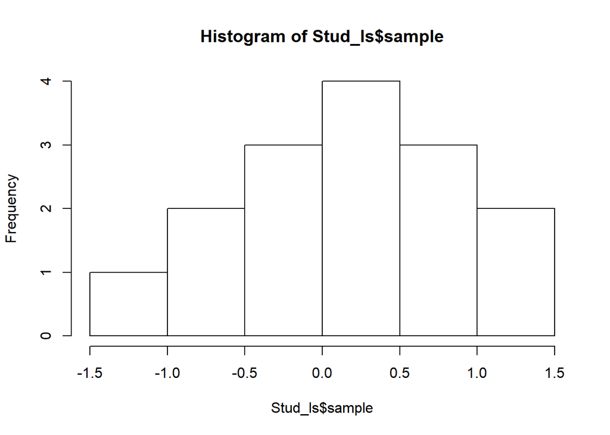

```r
hist(Stud_ls$sample)
```

```r
summary(Stud_ls$sample)
```

```
##     Min.  1st Qu.   Median     Mean  3rd Qu.     Max.
## -1.32945 -0.22879  0.15090  0.08411  0.58400  1.16501
```

```r
var(Stud_ls$sample)
```

```
## [1] 0.4940456
```

```r
# H0: mean = 0
# Ha: mean !=0

t_Stud <- t.test(
  Stud_ls$sample,
  alternative = "two.sided",
  mu = 0)

class(t_Stud)
```

```
## [1] "htest"
```

```r
is.list(t_Stud) # true - is a list;
```

```
## [1] TRUE
```

```r
t_Stud$statistic
```

```
##         t
## 0.4634763
```

```r
abs(t_Stud$statistic) # absolute value of test statistics
```

```
##         t
## 0.4634763
```

```r
abs(t_Stud$statistic) > qt(0.975, 14)
```

```
##     t
## FALSE
```

```r
t_Stud$p.value # how much we are wrong
```

```
## [1] 0.6501464
```

```r
Stud_ls[["Absolute value of Test Statistics (TS)"]]<- abs(t_Stud$statistic)
Stud_ls[["Critical Value (CV)"]]<- qt(0.975, 14)
Stud_ls[["p-value"]]<- t_Stud$p.value
Stud_ls[["Reject"]]<- abs(t_Stud$statistic) > qt(0.975, 14) # Fail to reject if false
Stud_ls
```

```
## $DistName
## [1] "Student's t"
##
## $params
## nu
##  4
##
## $sample
##  [1] -0.94022404 -0.11052487 -0.23322830  0.02278424  1.04059881
##  [6]  0.15089973  0.61836067 -0.22434518  0.69150191  0.32586458
## [11]  0.22234408 -1.32944886 -0.68753652  0.54964817  1.16500728
##
## $hist
## $breaks
## [1] -1.5 -1.0 -0.5  0.0  0.5  1.0  1.5
##
## $counts
## [1] 1 2 3 4 3 2
##
## $density
## [1] 0.1333333 0.2666667 0.4000000 0.5333333 0.4000000 0.2666667
##
## $mids
## [1] -1.25 -0.75 -0.25  0.25  0.75  1.25
##
## $xname
## [1] "Stud_ls$sample"
##
## $equidist
## [1] TRUE
##
## attr(,"class")
## [1] "histogram"
##
## $`Absolute value of Test Statistics (TS)`
##         t
## 0.4634763
##
## $`Critical Value (CV)`
## [1] 2.144787
##
## $`p-value`
## [1] 0.6501464
##
## $Reject
##     t
## FALSE
```

TS is less then CV and P-value is larger then alpha. Fail to reject the H0.

*Binomial - Symmetric, Discrete.*

```r
Binom_ls<- list(
  DistName ="Binomial",
  params = c(n = 9, p = 2/3),
  sample = rbinom(n=15, size=9, prob=2/3)
  )

Binom_ls$hist<- hist(Binom_ls$sample)
Binom_ls$hist
```

```
## $breaks
## [1] 3 4 5 6 7 8 9
##
## $counts
## [1] 3 3 5 2 1 1
##
## $density
## [1] 0.20000000 0.20000000 0.33333333 0.13333333 0.06666667 0.06666667
##
## $mids
## [1] 3.5 4.5 5.5 6.5 7.5 8.5
##
## $xname
## [1] "Binom_ls$sample"
##
## $equidist
## [1] TRUE
##
## attr(,"class")
## [1] "histogram"
```

```r
Binom_ls[c("DistName", "params")]
```

```
## $DistName
## [1] "Binomial"
##
## $params
##         n         p
## 9.0000000 0.6666667
```

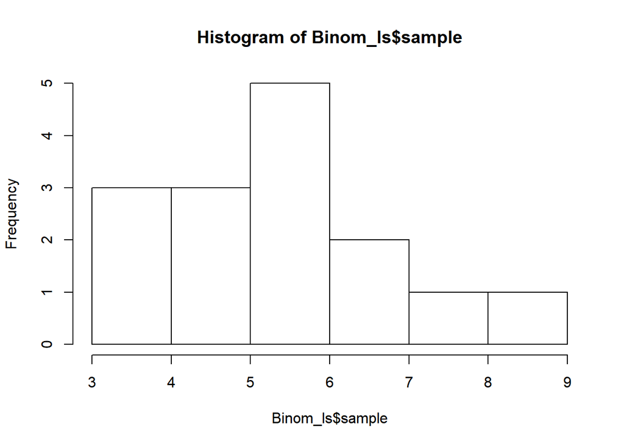

```r
hist(Binom_ls$sample)
```

```r
summary(Binom_ls$sample)
```

```
##    Min. 1st Qu.  Median    Mean 3rd Qu.    Max.
##   3.000   5.000   6.000   5.667   6.500   9.000
```

```r
var(Binom_ls$sample)
```

```
## [1] 3.095238
```

```r
t.test(Binom_ls$sample)
```

```
##
##  One Sample t-test
##
## data:  Binom_ls$sample
## t = 12.475, df = 14, p-value = 5.676e-09
## alternative hypothesis: true mean is not equal to 0
## 95 percent confidence interval:
##  4.692383 6.640951
## sample estimates:
## mean of x
##  5.666667
```

```r
# H0: mean = 6
# Ha: mean !=6

t_Binom <- t.test(
  Binom_ls$sample,
  alternative = "two.sided",
  mu = 6)

class(t_Binom)
```

```
## [1] "htest"
```

```r
is.list(t_Binom) # true - is a list;
```

```
## [1] TRUE
```

```r
t_Binom$statistic
```

```
##          t
## -0.7337994
```

```r
abs(t_Binom$statistic) # absolute value of test statistics
```

```
##         t
## 0.7337994
```

```r
abs(t_Binom$statistic) > qt(0.975, 14)
```

```
##     t
## FALSE
```

```r
t_Binom$p.value # how much we are wrong
```

```
## [1] 0.4751813
```

```r
Binom_ls[["Absolute value of Test Statistics (TS)"]]<- abs(t_Binom$statistic)
Binom_ls[["Critical Value (CV)"]]<- qt(0.975, 14)
Binom_ls[["p-value"]]<- t_Binom$p.value
Binom_ls[["Reject"]]<- abs(t_Binom$statistic) > qt(0.975, 14) # Fail to reject if false
Binom_ls
```

```
## $DistName
## [1] "Binomial"
##
## $params
##         n         p
## 9.0000000 0.6666667
##
## $sample
##  [1] 8 6 7 7 6 3 3 3 6 5 5 6 6 9 5
##
## $hist
## $breaks
## [1] 3 4 5 6 7 8 9
##
## $counts
## [1] 3 3 5 2 1 1
##
## $density
## [1] 0.20000000 0.20000000 0.33333333 0.13333333 0.06666667 0.06666667
##
## $mids
## [1] 3.5 4.5 5.5 6.5 7.5 8.5
##
## $xname
## [1] "Binom_ls$sample"
##
## $equidist
## [1] TRUE
##
## attr(,"class")
## [1] "histogram"
##
## $`Absolute value of Test Statistics (TS)`
##         t
## 0.7337994
##
## $`Critical Value (CV)`
## [1] 2.144787
##
## $`p-value`
## [1] 0.4751813
##
## $Reject
##     t
## FALSE
```

TS is smaller then CV and P-value is larger then alpha, then do not reject H0.